# Stochastic Processes

Math 606, Spring 2023

Luc Rey-Bellet

University of Massachusetts Amherst

2024-01-15

# 1 Continuous time Markov chains

In this section that we build a continuous time Markov process $X_t$ with $t\ge 0$. The Markov property can be expressed as
$$P\{ X_t=j| \{X_{r}\}, 0\le r \le s \} = P\{X_t=j| X_s \} \,.$$
for any $0 < s < t$.

## Exponential random variables

To construct a Markov we will need lots of exponential random variables. Recall that an exponential random variable $T$ with paramter $\lambda$ has the pdf $f_T(t)=\lambda e^{-\lambda t}$, for $t \ge 0$ the cdf $F_T(t) = 1- e^{-\lambda t}$ and mean $E[T]=\frac{1}{\lambda}$.

**Proposition 1.1 (Properties of exponential randomm variables)** Let $T_1, T_2, T_3, \cdots$ be independent exponential random variables with parameter $\lambda_1, \lambda_2, \cdots$. Then

1. $T= \min\{ T_1, \cdots, T_n\}$ is an exponential random variables with paramter $\lambda_1+ \cdots \lambda_n$. Note that $n=\infty$ is allowed if we assume that $\sum_{n}\lambda_n$ is finite.
2. $\displaystyle P\{ T_i = \min \{ T_1, \cdots, T_n\} \} = \frac{\lambda_i}{\lambda_1+ \cdots \lambda_n}$

*Proof*. For 1. we have, using independence,
$$P\left\{ T > t \right\} = P\left\{ T_1 > t, \cdots, T_n > t \right\} = P\left\{ T_1 > t \right\} \cdots P\left\{ T_m > t \right\}
= e^{-(\lambda_1+ \cdots \lambda_n)t}$$
and thus $T$ is an exponential random variable.
For 2. we have, by conditioning,
$$P\left\{ T_1 = T \right\} = \int_0^\infty P\{ T_2>t, \cdots, T_n > t \} f_{T_1}(t) \, dt = \int_0^\infty e^{-(\lambda_2 + \cdots+ \lambda_n)t} \lambda_1 e^{-\lambda_1 t}\, dt = \frac{\lambda_1}{\lambda_1+ \cdots \lambda_n}$$
$\blacksquare$

## Definition of a continuous time Markov chain

- As for the Poisson process we will give two equivalent definition of the process, the first one describe infinitesinmal rate of change and leads to a *system of ODEs* describing the evolution of the pdf of $X_t$. The second definition use exponential random variables and waiting times and leads to an algorithm to simulate a continuous time Markov chain, often called the *stochastic simulation algorithm*.
- To define a Markov process on the state space $S$ we assign a number $\alpha(i,j)$ for any pair of state $i\not=j$. You should think these numbers
  $$\alpha(i,j) = \textrm{ rate at which the chain changes from state } i \textrm{ to state } j \,.$$
  We denote
  $$\alpha(i) = \sum_{j\not= i} \alpha(i,j) = \textrm{ rate at which the chain changes from state } i \,.$$
- Formally a continuous Markov chain with rates $\alpha(i,j)$ is a stochastic process such that
  $$\begin{aligned}
  P\{ X_{t+\Delta t}=i| X_t=i\} &= 1 - \alpha(i)\Delta t + o(\Delta t) \\
  P\{ X_{t+\Delta t}=j| X_t=i\} &= \alpha(i,j)\Delta t + o(\Delta t)
  \end{aligned}$$
- Proceeding as for the Poisson process we can derive a differential equation for $p_t(i)=P\{X_t =i\}$. By conditioning we have
  $$P\{ X_{t+\Delta t}=i\} = (1 - \alpha(i)\Delta t )P\{ X_t=i\} + \sum_{j \not =i} \alpha(j,i)\Delta t P\{ X_t=j\} + o(\Delta t)$$
  which leads to the system of linear ODE’s
  $$\frac{d}{dt}p_t(i) = -\alpha(i) p_t(i) + \sum_{j \not= i} \alpha(j,i) p_t(j)
  \tag{1.1}$$
  called the *Kolmogorov backward equations*.
- The infinitesimal generator of a continuous-time Markov chain is given by the matrix
  $$A =
  \begin{matrix}
  1 \\ 2 \\ 3 \\ \vdots
  \end{matrix}
  \begin{pmatrix}
  -\alpha(1) & \alpha(1,2) & \alpha(1,3) & \cdots \\
  \alpha(2,1) & -\alpha(2) & \alpha(2,3) & \cdots\\
  \alpha(3,1) & \alpha(3,2) & -\alpha(3) & \cdots\\
  \vdots & \vdots & \vdots &
  \end{pmatrix}$$
  and the entries of $A$ satifies
  $$A(i,j)\ge 0 \textrm{ for } i \not= j \quad \textrm{ and } \sum_{i} A(i,i) = 0$$
- If we use a row vector $p_t = (p_t(1), p_t(2), \cdots)$ then we can rewrite Equation 1.1 as the system
  $$\frac{d}{dt}p_t = p_t A
  \tag{1.2}$$
- If *$S$ is finite* then one can write the solution in terms of the matrix exponential $e^{tA}= \sum_{k=0}^\infty \frac{t^k A^k}{k!}$
  $$p_t = p_0 e^{tA} \,.$$
  where $p_o(i)=P\{X_0=i\}$ is the initial distribution.
- We can also write equation for the transition probabilities (take $X_0=i$)
  $$P_t(i,j) = P \{ X_t =j| X_0=i\}$$
  and we obtain the matrix equation
  $$\frac{d}{dt}P_t = P_t A, \quad \textrm{ with } P_0 =I \quad \implies \quad P_t = e^{tA}$$
  which we can solve using linear algebra techniques

## Alternative description

We can also construct the Markov chain $X_t$ using exponential random variable.

- If $X_t=i$ consider (independent) random variable $T(i,j)$ with parameter $\alpha(i,j)$ for $j \not =i$. Think of those as exponential clocks and when the first of the clocks rings, say clock $j$, then the Markov chain moves to state $j$.
- Using Proposition 1.1 we see that the chain moves from the state $i$ to $j$ if the clocks associated to the pair $(i,j)$ rings first and this occur with probability
  $$Q(i,j) = \frac{\alpha(i,j)}{\sum_{j \not= i}\alpha(i,j)} = \frac{\alpha(i,j)}{\alpha(i)}$$
- The matrix $Q(i,j)$ is the transition matrix for a discrete time Markov chain $Y_n$ which has the same junmps probabilities as $X_t$ but the transition occur at each unit time.
- Then a new set of clocks with rates $\alpha(j,k)$ is produced and the process starts anew until the Markov chain moves to a new state.
- By Proposition 1.1 we can express this slightly differently. If in state $i$ we use a single clock with rate $\alpha(i)$ and when this clock rings then we move to state $j$ according to the discrete time Markov chain $Q(i,j)$.
- The Markov property follows form the memoryless property for an exponential distribution $T$: $P(T\ge t +s| T \ge s) = P(T>t)$.
- If $X_t=i$ then by construction the *position after the next jump after time $t$* clearly depends only $i$ and not the states that the Markov chain visited before time $t$. Moreover if we consider the time of the last jump before time $t$ which occured, say at time $s<t$, then the memoryless property of the exponential random variable implies that the *time at which the jump occur after time $t$* does not depend on $s$ at all. Putting these together this implies the Markov property
  $$P\{X_{t+u} =j | X_{s}, 0 \le s \le t\} = P\{X_{t+u} =j | X_t \}$$
- To connect this to the previous description we note that by conditioning on the first jump
  $$P_t(i,j) = P(X_t=j|X_0=i) = \delta(i,j) e^{-\alpha(i) t} + \int_0^t \alpha(i) e^{-\alpha(i)s} \sum_{k} {Q(i,k)} P_{t-s}(k,j) ds$$
  Iterating this equation and setting $t=\Delta t$ we find
  $$\begin{aligned}
  P(X_{\Delta t}=j|X_0=i) &= \delta(i,j) e^{-\alpha(i) \Delta t} + \int_0^t \alpha(i) e^{-\alpha(i)s} \sum_{k} \frac{\alpha(i,k)}{\alpha(i)} \delta(k,j) e^{-\alpha(k)(t-s)} ds + \cdots \\
  &= \delta(i,j) e^{-\alpha(i) \Delta t} + \alpha(i,j) \Delta t \times \underbrace{ e^{-\alpha(j) \Delta t}
  \frac{1}{\Delta t} \int_0^{\Delta t} e^{-(\alpha(i)-\alpha(j)) s} ds
  }_{\to 1 \textrm{ as }\Delta t \to 0} + \cdots \\
  &= \delta(i,j) (1 - \Delta t \alpha(i)) + \alpha(i,j) \Delta t + o(\Delta t)
  \end{aligned}$$
  The higher order terms are negligible since the probability to have two jumps in the time interval $[0,\Delta t]$ is $o(\Delta t)$.

## Uniformizable chain

- Consider a Markov chain $Y_n$ with transition matrix $Q$ and we assume that $Q(i,i)=0$. Then we pick rate $\lambda(i)=1$ for all states $i$. The times at which the Markov chain has transition is thus a sum of IID exponential, that at time descriebed by a Poisson process. In other terms we have
  $$X_t = Y_{N_t}$$
  where $N_t$ is a Poisson process with rate $1$.
- In this case we can compute the transition matrix quite explicitly:
  $$\begin{aligned}
  P\{X_t=j|X_0=i\}& = P\{ Y_{N_t}=j| X_0=i\} \\
  &= \sum_{n=0}^\infty P\{ Y_{N_t}=j, N_t=n| X_0=i\} \\
  &= \sum_{n=0}^\infty P\{ Y_n=j| X_0=i\} P\{N_t=n\} \\
  &= \sum_{n=0}^\infty \frac{e^{-\lambda t} (\lambda t)^n}{n!} Q^n(i,j)
  \end{aligned}$$

and the generator is given by $A = (Q-I)$.

## Stationary distributions and detailed balance

- A probability vector $\pi$ is a stationary distribution for the Markov chain with generator $A$ if
  $$\pi P_t = \pi \quad \textrm{ for all } t =0$$
  which, by Komlogorov equation, is equivalent to
  $$\pi A = 0$$
- In terms of the rate $\alpha(i,j)$ we see that $\pi$ is stationary if ansd only if
  $$\sum_{i \not= j} \pi(i) \alpha(i,j) = \pi(j)\alpha(j) = \sum_{i \not=j}
  \pi(j) \alpha(j,i)$$
  which we can interpret as a balance equation: $\pi(i)\alpha(i,j)$ is the rate at which the chain in a state $\pi$ changes from $i$ to $j$.
- As for discrete time we say that a Markov chain satisfies detailed balance if
  $$\pi(i) \alpha(i,j) = \pi(j) \alpha(j,i) \textrm{ for all } i \not= j$$
  and detailed balance obviously implies stationarity.
- The Markov chain with generator $A$ is irreducible if for any pair of states $i,j$ we can find states $i_1, \cdots, i_{N-1}$ such that
  $$\alpha(i,i_1) \alpha(i_2, i_3) \cdots \alpha(i_{N-1},j) >0$$
  If there exists a stationary distribution for an irreducible chain then $\pi(i)>0$ for all $i$. Indeed if $\pi(i)>0$ and $\alpha(i,j)>0$ then $\pi A(j) =0$ implies that $\pi(j)\alpha(j) = \sum_{k}\pi(k)\alpha(k,j) \ge \pi(i)\alpha(i,j)>0$ and thus $\alpha(j)>0$.
- The issue of periodicity cannot occur for continuous time Markov chains

**Lemma 1.1** For an irreducible Markov chain with generator $A$, $P_t(i,j)>0$ for all $i,j$ and all $t>0$.

*Proof*. Using the Markov property
$$\begin{aligned}
P\{X_t=j|X_0=i\} &\ge P \{ X_{t/N}=i_i, X_{2t/N}=i_2, \cdots X_{t}=j |X_0=i\} \\
&= P \{ X_{t/N}=i_1| X_0=i\} P\{ X_{2t/N}=i_2| X_{t/N}=i_i\} \cdots P\{ X_{t}=j |X_{t\frac{N-1}{N}}=i_{n-1}\}
\end{aligned}$$
and for example
$$P \{ X_{t/N}=i_1| X_0=i\} \ge \int_0^{t/N} \alpha(i) e^{-\alpha(i)s} Q(i,i_1)
e^{-\alpha(i_1)(t-s)}>0$$
$\blacksquare$

## Convergence to the stationary distribution

If the state space is finite and the chain is irreducible then we have convergence to equilibrium.

**Theorem 1.1** If the state space $S$ is finite and the Markov chain with generator $A$ is irreducible then for any initial distribution $\mu$ we have
$$\lim_{t \to \infty}\mu P_t = \pi$$

The vector $1=(1,1, \cdots,1 )^T$ is a right eigenvector for $A$ and $\pi$ is a left eigenvector for $A$. If we define the matrix $\Pi$ as the matrix whose rows are equal to $\pi$, we have then
$$(P^t - \Pi) \begin{pmatrix} 1\\ \vdots \\1 \end{pmatrix}= 0 \textrm{ and } \pi(P^t - \Pi) =0\,.$$
Moreover if $f$ the right eigenvector and $g$ the left eigenvector for $A$ for the eigenvalue $\mu \not=0$ then we have
$$\pi (Af) = \mu \pi f = (\pi A) f =0 \quad \textrm{ and } (g A) 1 = g (A1) = \mu g 1 =0$$
and thus we must have $\pi f=0$ and $g 1 =0$. Therefore
$$P^t - \Pi)f = P^t f = e^{\mu t} f \textrm{ and } g(P^t - \Pi) = gP^t = e^{\mu t} g.$$
This implies that $P^t - \Pi$ has the simple eigenvalue $0$ and the same eigenvalues $e^{\mu t}$ as $P^t$ and $\mu$ has strictly negative real part. Therefore $P^t - \Pi$ converges to $0$ as $t \to \infty$, or
$$\lim_{t \to \infty} P_t(i,j)= \pi(j) .$$

## Transient behavior

To study the transient behavior in continuous time we can use similar ideas as in discrete time.

- *Absorption probabilities*: the absorption probabilities do not depend on the time spent in every state so they can be computed using the transition matrix $Q(i,j)$ for the embedded chain $Y_n$ and the formula in Section [Absorption probabilities]
- *Expected hittiing time*: For example we have the following result

**Theorem 1.2** Supose $X_t$ is a Markov chain with generator $A$ and for $i\not j$ let
$$\Sigma(j) = \inf\{t \ge 0 ; X_t=i\}$$
be the first hitting time to state $j$. Let $\tilde{A}$ the matrix obtained by deleting the $j^{th}$ and $j^{th}$ column from the generator $A$. Then we have
$$E[\Sigma(j)|X_0=i] = \sum_{l \not= j} B(i,l) \quad \textrm{ where } B= \tilde{A}^{-1}$$
The matrix $\tilde{A}$ has rowsums which are non-positive and at least one of the row must be strictly negative.

*Proof*. By conditioning on the first jump which happens at time $T$ we have
$$E[\Sigma(j)|X_0=i] = \underbrace{E[T|X_0=i]}_{\textrm{expected time until the first jump }} + \sum_{k\in S, k\not=j} P\{ X_T = k|X_0=i\} \underbrace{E[ \Sigma(j)|X_0=k]}_{\textrm{expected hitting time} \atop \textrm{ from the state after the first jump}}$$
If we set $b(i)=E[\Sigma(j)|X_0=i]$ (for $i \not= j$) we find the equation
$$b(i)= \frac{1}{\alpha(i)} + \sum_{k \not= j} \frac{\alpha(i,k)}{\alpha(i)} b(k) \implies 1 = \alpha(i) b(i) - \sum_{k\not= j}\alpha(i,k) b(k)$$
which reads, in matrix form as
$$1 = -\tilde{A} b \implies b= (-\tilde{A})^{-1} 1.$$
To show that $-\tilde{A}$ is invertible we consider the matrix $R= \frac{1}{a}\tilde{A} + I$ where $a$ is chosen larger than all the entries. Then the entries of $R$ are non-negative and the rowsums do not exceed one with at least one strictly less than $1$. By the results for discrete time Markov chains we know that
$$I-R=(-\frac{1}{a} A)$$
is invertible.

## Explosion

- For a continuous time Markov chain $X_t$ let us consider the time of the successive jumps
  $$S_1=T_1, S_2=T_1+T_2, S_3=T_1+T_2+T_3, \cdots$$
  Here the $T_i$ are independent exponential but, in general, no identically distributed with paramters $\alpha_i$ which depends on the state being visited. We have then
  $$E[S_n]= \sum_{i=1}^n \frac{1}{\lambda_i}$$
- *Explosion*: To see what can happen consider a Markov chain with rate $\alpha(i,i+1)=(n+1)^2$ and all other rates equal to $0$. Then the Markov chain moves up by $1$ at every jump like a Poisson process but at accelerated pace. We have then
  $$E[S_\infty]= \sum_{n=1}\frac{1}{n^2} < \infty$$
  so $S_\infty < \infty$ with probability $1$. So there are infinitely many jumps in finite time and $X_t=+\infty$ after a finite time. This is called explosion.
- This is an issue familiar in ODE: the equation $\frac{d}{dt} x_t = x_t^2$ has solution has solution $x_t= \frac{x_0}{x_0-t}$ which blows up at time $t=x_0$.
- It is not easy to determine if an explosion really occurs. Indeed for no explosion to occur we must have, with probabilty 1,
  $$\sum_{n} \frac{1}{\alpha(Y_n)} = \infty$$
  where $Y_n$ is the embedded chain.
- A sufficient condition for non-explosion is a suitable upper bound on the rates $\alpha(i)$, say $\alpha(i) \le \alpha$ which is true for finite state spaces but this is by no means necessary.

## Transience, recurrence, and positive recurrence.

- The recurrence and transience for a continuous time Markov chain can be defined as for discrete time. A an irreducbile Markov chain $X_t$ is recurrent if the chain starting from a state $i$ returns to $i$ with probability $1$ and transient if $X_t$ never return to $i$ with some non-zero probability.
- Transience/recurrence has nothing to do with the actual time spent in every state and so we have immediately
  $$X_t \textrm { with rates } \alpha(i,j) \textrm{ is } \begin{array}{l} \textrm{transient} \\ \textrm{recurrent}\end{array} \iff
  Y_n \textrm{ with transition } Q(i,j)=\frac{\alpha(i,j)}{\alpha(i)}
  \textrm{ is } \begin{array}{l} \textrm{transient} \\ \textrm{recurrent}\end{array}$$
- For positive recurrence we need to define the first return to a state $i$. This is most easily defined in terms of the return for the embeded Markov chain $Y_n$ and its first return time $\tau(i)$. The time until $X_0$ returns to $i$ will the sum of the time spent in each state. If $S_n$ denotes the time of the jumps and $\tau(i)=n$ after visiting the state $j_0, j_1, \cdots j_{n-1}, j_n=i$ then the return time is
  $$\sum_{k=0}^{n-1}(S_{k+1}- S_k)$$
  where $S_{k+1}-S_k$ is exponential with paramter $\alpha(j_k)$. The first return time to state $i$ for the Markov chain $X_t$ is given
  $$\Sigma(i) = \sum_{k=0}^{\tau(i)-1}(S_{k+1}- S_k)$$

## Stationary distribution for recurrent chains

**Theorem 1.3** If the Markov chain with rates $\alpha(i,j)$ is irreducible and recurrent, then there exists a unique solution (up to a multiplicative constant) $\eta=(\eta(1), \eta(2), \cdots)$ to the equation $\eta A=0$ with
$$0 < \eta(i) < \infty \,.$$
If it holds that $\sum_{i}\eta(i) < \infty$ then $\eta$ can be normalized to a stationary distribution and $X_t$ is positive recurrent.

*Proof*. The equation $\eta A(k)=0$ can be written as
$$\sum_{j \not= k} \eta(j) \alpha(j,k) = \alpha(k) \eta(k) \iff \sum_{j \not= k} \eta(j)\alpha(j) Q(j,k) = \eta(j)\alpha(j)$$
That is the row vector $\mu$ with entries $\mu(k)=\alpha(k) \eta(k)$ must satisfy $\mu Q = \mu$.

If we denote by $S_n$ the time of the $n^{th}$ jump for $X_t$ we have
$$\begin{aligned}
\eta(j) &= \sum_{k=0}^\infty E\left[ \frac{1}{\alpha(j)} {\bf 1}_{\{Y_k=j\}} {\bf 1}_{\{\tau(i) >k\}} \right] = \sum_{k=0}^\infty E\left[ (S_{k+1} -S_k) {\bf 1}_{\{Y_k=j\}} {\bf 1}_{\{\tau(i) >k\}} \right]
= E\left[ \sum_{k=0}^{\tau(i)-1} (S_{k+1} -S_k) {\bf 1}_{\{Y_k=j\}} \right]
\end{aligned}$$
which is nothing but the time spent (by $X_t$) in the state $j$ between successive visits to $i$.

If $\sum_{j} \eta(j) <\infty$ then we have
$$E[\Sigma(j)]=E\left[ \sum_{k=0}^{\tau(i)-1} (S_{k+1} -S_k)\right] <\infty$$
which is the expected return time to state $i$. That is the chain $X_t$ is positive recurrent.

## Ergodic theorem for positive recurrent Markov chains

We have the following theorem which is the exact counterpart of the discrete time case (and is proved very similarly so we will omit the proof).

**Theorem 1.4** Suppose $X_t$ is irreducible and positive recurrent. Then $X_t$ has a unique stationary distribution, and with probability $1$, the time spent in state $j$, converges to $\pi(j)$
$$\lim_{t\to \infty}\int_0^t \mathbf{1}_{\{X_s=j\}} \, ds = \pi(j).$$
Moreover we have Kac’s formula: $\pi(j)$ is also equal to the average time between consecutive visits to state $j$:
$$\pi(j) = \frac{1}{E[\Sigma(j)|X_0=j]}.$$
Conversely if $X_t$ has a stationary distribution then $X_t$ is positive recurrent.

## Birth and death process

- A general birth and death process is a continuous time Markov chain with state space $\{0,1,2,\cdots\}$ and whose only non-zero transition rates are
  $$\begin{aligned}
  &\lambda(n) = \alpha(n,n+1) & = \textrm{ birth rate for a population of size } n & (\textrm{ for } n\ge 0) \\
  &\mu(n)=\alpha(n,n-1) & = \textrm{ death rate for a population of size } n & (\textrm{ for } n\ge 1)
  \end{aligned}$$
- The Kolmogorov equations for the distribution of $X_t$ are, for $n\ge 1$
  $$\frac{d}{dt}p_t(n) = \underbrace{ \mu(n+1) p_t(n+1)}_{\textrm{ increase due do death} \atop \textrm{in a population of size } n+1} +
  \underbrace{\lambda_{n-1} p_t(n-1)}_{\textrm{ increase due do birth} \atop \textrm{in a population of size } n-1} - \underbrace{(\lambda(n) + \mu(n))p_t(n)}_{\textrm{ decrease due do birth/death} \atop \textrm{in a population of size} n}.$$
  For $n=0$, the eqation reads $\displaystyle \frac{d}{dt}p_t(0)= \mu(1) p_t(1) - \lambda(0) p_t(0)$.
- The generator has the form
  $$\begin{matrix}
  0 \\ 1 \\ 2\\ \vdots
  \end{matrix}
  \begin{pmatrix}
  -\lambda(0) & \lambda(0) & 0 & 0 & \dots \\
  \mu(1) &-\lambda(1) -\mu(1) & \lambda(1) & 0 & \dots \\
  0 & \mu(2) &-\lambda(2) -\mu(2) & \lambda(2) & \dots \\
  \vdots & \ddots & \ddots & \ddots & \\
  \end{pmatrix}$$
- The transition matrix for the embedded process $Y_n$ is

$$\begin{matrix}
0 \\ 1 \\ 2\\ \vdots
\end{matrix}
\begin{pmatrix}
0 & 1 & 0 & 0 & \dots \\
\frac{\mu(1)}{\mu(1)+ \lambda(1)} & 0 & \frac{\lambda(1)}{\mu(1)+ \lambda(1)} & 0 & \dots \\
0 & \frac{\mu(2)}{\mu(2)+ \lambda(2)} & 0 & \frac{\lambda(2)}{\mu(2)+ \lambda(2)} & \dots \\
\vdots & \ddots & \ddots & \ddots & \\
\end{pmatrix}$$
which is the transition matrix of a general random walk on the non-negative integers.

## Examples

- *Poisson process*: There is no death and the birth rate is constant
  $$\mu(n)=0 \quad \textrm{ and } \quad \lambda(n)=\lambda$$
- *Queueing models:* Imagine a Poisson process (with rate $\lambda$) describing the arrival of customers. In the systems there are $k$ service station at which the service time is exponential with rate $\mu$. If one service station is empty, upon arrival a customer immediately enter a service station and stay in the system until being served. If all stations are currently busy serving other customers, the customer wait until one stay becomes free. These models are called $M/M/k$ queues where $M$ statnds for Markovian and $k$ is the number of queues, the first $M$ describing the arrival process and the second $M$ the service time (which is exponential).
- $M/M/1$ queue: If there is only one service station
  $$\lambda(n)=\lambda \quad \textrm{ and } \quad \mu(n) =\mu$$
- $M/M/k$ queue: If there is $k$ service station then the rates are
  $$\lambda(n)=\lambda \quad \textrm{ and } \quad \mu(n) = \left\{ \begin{array}{cl} n \mu & n \le k \\ k \mu & n > k \end{array} \right.$$
- $M/M/\infty$ queue: If there is $k$ service station then the rates are
  $$\lambda(n)=\lambda \quad \textrm{ and } \quad \mu(n) =n\mu$$
- *Population models*: If $X_t$ describes the size of a population birth rate will be naturally proportional to the size of the population if we assume that all individuals give birth or die with a certina rate.
  - Pure birth model: no death occur and so
    $$\lambda(n)=n \lambda \quad \textrm{ and } \quad \mu(n) = 0$$
  - Population model: the rates
    $$\lambda(n)=n \lambda \quad \textrm{ and } \quad \mu(n) = n \mu$$
  - Population model with immigration: if immigrants arrive acccording to a Poisson process with rate $\nu$ the rates are
    $$\lambda(n)=n \lambda +\nu \quad \textrm{ and } \quad \mu(n) = n \mu$$

## Recurrence

- To study postive recurrence we simply solve for the stationary distribution $\pi A=0$. The first equation (for $n=0$) gives
  $$\mu(1) \pi(1) - \lambda(0)\pi(0) =0
  \tag{1.3}$$
  and
  $$\lambda(n-1) \pi(n-1) + \mu(n+1) \pi(n+1) - (\mu(n)+ \lambda(n))\pi(n)=0 \textrm{ for } n\ge 1$$
  or
  $$\mu(n+1)\pi(n+1)-\lambda(n) \pi(n)=\mu(n)\pi(n)-\lambda(n-1) \pi(n-1)
  \tag{1.4}$$
  Combining Equation 1.3 and Equation 1.4 gives
  $$\pi(n) = \prod_{j=1}^n \frac{\lambda(j-1)}{\mu(j)} \pi(0)$$
  and thus we have a stationary distribution if and only if
  $$\sum_{k=1}^\infty \prod_{j=1}^k \frac{\lambda(j-1)}{\mu(j)} <\infty\,.$$
- The Poisson process are bure birth models are not irreducible and converge to $+\infty$ almost surely.
- $M/M/1$-queue: $\prod_{j=1}^n \frac{\mu(j)}{\lambda(j)}=\left(\frac{\lambda}{\mu}\right)^n$
  - Transient if $\mu < \lambda$.
  - Recurrent if $\mu =\lambda$
  - Positive recurrent if $\lambda < \mu$ and with (geometric) stationary distribution: $\pi(n)= \frac{\left(\frac{\lambda}{\mu}\right)^n}{1 -\frac{\lambda}{\mu} }$
- $M/M/k$-queue: $\prod_{j=1}^n \frac{\mu(j)}{\lambda(j)} = \left\{ \begin{array}{cl} n! \left( \frac{\mu}{\lambda} \right)^n & n < k \\ \frac{k!}{k^k} \left(\frac{k\mu}{\lambda}\right)^n & n \ge k \end{array} \right. .$
  - Transient if $k \mu < \lambda$.
  - Recurrent if $k \mu =\lambda$
  - Positive recurrent if $\lambda < k \mu$, the stationary $\pi$ is a bit messy to write.
- $M/M/\infty$-queue: $\prod_{j=1}^n \frac{\mu(j)}{\lambda(j)}= n! \left( \frac{\mu}{\lambda} \right)^n$.
  - Always positive recurrent with Poisson stationary distribution $\pi(n) = e^{- \frac{\lambda}{\mu}} \frac{ \left(\frac{\lambda}{\mu}\right)^n}{n!}$

# 2 Brownian motion

## Definition of Brownian motion

- The Brownian motion $X_t$, $t\ge 0$, is a stochastic process taking value in $\mathbb{R}$ (or $\mathbb{R}^d$ ) and a model for random continuous motion taking place in space.
- By convention we set $X_0=0$ and start at $0$. Saying that the motion is completely random does not mean that $X_t$ and $X_s$ are independent but rather that the motion after time $s$, that is $X_t-X_s$, should be idependent of $X_s$. More generally we will assume the property of independent increments like we did for the Poisson process $N_t$. We will also assume that the moition does not have any prefered disrection so we must have $E[X_t]=0$. In addition we will require that the map $t \to X_t$ are continuous. If the paths are not continuous then $N_t-t$ satisfies thses requirements. But requirement of continuity of the paths actually imply that the *only* possibility is for the increments to be normally distributed.
- Formally a Brownian motion or Wiener process with variance parameter $\sigma^2$ is a stochastic process $X_t$ such that
  1. $X_0=0$.
  2. Independent increments: For any $n>1$ and times $s_1\le t_1\le s_2 \le t_2 \le \cdots \le s_n \le t_n$ the random variables $X_{t_1}-X_{s_1}$, $X_{t_2}-X_{s_2}$ $\cdots$ $X_{t_N}-X_{s_n}$ are independent.
  3. For any $s< t$ the random variables $X_t-X_s$ has a normal distribution with mena $0$ and variance $\sigma^2(t-s)$.
  4. The paths are continuous.

  As mentioned before, 3. actually follows from the other assumptions.

## Brownian motion as limit of random walks

Let $Y_1, Y_2, \cdots$ be IID random variable with $E[Y_n]=0$ and $\textrm{ Var}(Y_n)=1$. Then a random walk is defined by
$$S_0=0, \quad S_n=Y_1 + \cdots + Y_n\,.$$
We now define a process $X^{(n)}_t$ by rescaling time and the size of the increments to obtain a proper limit
$$X^{(n)}_t = \frac{S_{\lfloor n t \rfloor}}{\sqrt{n}} \quad \textrm{ for }t\ge 0$$
To understand this scaling note that if, say, $t=1$ we have $X^{(n)}_1=\frac{Y_1+ \cdots + Y_n}{\sqrt{n}}$ which has mean $0$ and variance $1$ which is independent of $n$ and we can hope to have a well-defined limit. Using now the central limit theorem we find
$$X^{(n)}_t = \frac{S_{\lfloor n t \rfloor}}{\sqrt{n}}
= \frac{S_{\lfloor n t \rfloor}}{\sqrt{\lfloor n t \rfloor}}
\times \frac{\sqrt{\lfloor n t \rfloor}}{\sqrt{n}} \to t Z \quad \textrm{ in distribution}$$
which has same distribution as $X_t$. Similarly
$$X^{(n)}_t-X^{(n)}_s = \frac{S_{\lfloor n t \rfloor} -S_{\lfloor n s \rfloor} }{\sqrt{n}} = \frac{1}{\sqrt{n}} \sum_{j=\lfloor n s \rfloor +1}^{\lfloor n t \rfloor} X_j
\to (t-s) Z \quad \textrm{ in distribution}$$
which has the same distribution as $X_t-X_s$. Stronger form of convergences can be proved which shows that the path of the process are actually continuous in the limit but this is too technical for now.

## Properties of Brownian motion

- **Probability distributions and the Markov property:** By definition $X_t$ is a time-homogeneous process since $X_{t+s}-X_s$ has the same distribution as $X_t$ and the Markov property follows from $X_t=X_s+ (X_t- X_s)$ which shows that the distribution of $X_t$ only depend on $X_s$. We have then
  $$P\{ X_{t+s} \in A | X_s=x\} = P\{ X_t \in A - x \} = \int_{A-x} \frac{1}{\sqrt{2\pi t}} e^{-\frac{y^2}{2t}} dy = \int_{A} \frac{1}{\sqrt{2\pi t}} e^{-\frac{(y-x)^2}{2t}} dy$$
  and so $X_t$ is a Markov chain with transition probability densities
  $$p_t(x,y)= \frac{1}{\sqrt{2 \pi t}} e^{-\frac{(y-x)^2}{2t}}$$
- **Reflection and Scaling**:
  $$X_t \textrm{ is a Brownian motion } \implies \left\{ \begin{array}{l} Y_t = - X_t \textrm{ is a Brownian motion } \\
  Z_t = \sqrt{a} X_{t/a} \textrm{ is a Brownian motion for any } a>0 \\ \end{array} \right.$$
  To see this one check that properties 1.-4. are satified in Definition of Brownian motion
- **Strong Markov property:**
  - By the property of idependent increments (which leads immediately to the Markov property) if $X_t$ is a Brownian motion then $Y_t = X_{t+s}- X_s$ is a Brownian motion.
  - A stopping time $T$ for a Brownian motion $X_t$ is random variable such that
    $$P\{ T \le t\} \textrm{ is measurable with respect to } \{X_s\}_{0\le s \le t}$$
    that is we now when to stop based on past information only.
  - The [strong Markov property] is the following theorem which is believable but would require a more formal proof.

  **Theorem 2.1** If $X_t$ is a Brownian motion and $T$ a stopping time for the Brownian motion $X_t$ then $X_{T+t} - X_T$ is Brownian motion.
- **Gaussian process**: $X_t$ is a Gaussian process in the sense that the joint distribution of $X_{t_1}, X_{t_2}, \cdots, X_{t_n}$ is a $n$ dimensional normal random variable. To see this note that $X_{t_1}, X_{t_2}-X_{t_1}, \cdots, X_{t_n}-X_{t_1}$ is a $n$ dimensional normal random variable (the components are independent) and that the two vector are related though a linear transformation.
  To compute the covaraince is enough to compute $E[X_s X_t]$ and we have
  $$\textrm{ For } s<t \quad E[X_s X_t]=E[X_s (X_s+ X_t-X_s)]= E[X_s^2] + E[X_s] E[X_t-X_s] = s$$
  and thus we find
  $$E[X_sX_t]= \min \{s,t\}$$
- **Reflection principle:**
  - Fix a value $a>0$ and consider the following hitting time
    $$T_a = \inf \{ t\ge 0, X_t=a\}$$
    that is $T_a$ is the first time the Brownian motion exceeds the value $a$.
    The following results shows that you can reflect the Brownian motion around the line $x=a$ after $T_a$ and still obtain a Brownian motion

**Theorem 2.2 (Reflection principle)** The process
$$Y_t = \left\{\begin{array}{cl} X_t & t \le T_a \\ 2a - X_t & t > T_a
\end{array} \right.$$
is a Brownian motion

*Proof*. The proof relies on the strong Markov property and the relfectyion property to tells us that
$$X_{T_a+s} - X_{T_a} = X_{T_a+s} - a \textrm{ and } a - X_{T_a+s}$$
are Brownian motions (starting at $0$) and so $2a - X_{T_a+s}$ is a Brownian motion starting at $a$. Therefore if we set $t=T_a+s$ for $t>T_a$ we see that $Y_t$ is Brownian motion

An illustration of the theorem is in the following figure

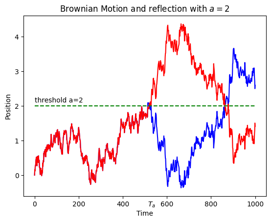

Reflection principle

Using the reflection principle we can analyse the distribution of the maximum of the Brownian motion over the time interval $[0,t]$
$$M_t = \max_{0\le s \le t} X_s$$

**Theorem 2.3 (Distribution of the maximum of Brownian motion)** We have
$$P\{ M_t \ge a \} = 2 P\{X_t \ge a\}\,.
\tag{2.1}$$
The pdf of $M_t$ is given by
$$f_{M_t}(a)= \sqrt{\frac{2}{\pi t}} e^{-\frac{a^2}{t}} \quad \textrm{ for } a >0$$
The pdf the first hitting time $T_a$ is given by
$$f_{T_a}(t)= \frac{a}{\sqrt{2 \pi}} t^{-3/2} e^{-\frac{a^2}{2t}} \quad \textrm{ for } t >0$$

*Proof* (Theorem 2.3). The proof of Equation 2.1 follows from the reflection principle.
$$P\{ M_t \ge a \} = P\{ M_t \ge a , X_t\le a\} + P\{ M_t \ge a , X_t > a\}$$
For the second term we note that if $X_t >a$ then $M_t\ge a$ and thus $P\{ M_t \ge a , X_t > a\}=P(X_t>a)$.

For the first term we use the reflection principle: the reflected path $Y_t$ is a Brownian motion and its first hitting time to $a$, say $S_a$ is identical to $T_a$ (see the picture). Therefore
$$\begin{aligned}
P\{ M_t \ge a , X_t\le a\} &= P\{ T_a\le t , X_t\le a\} = P\{ S_a \le t , Y_t\le a\} \\
&= P\{ T_a \le t , 2a - X_t\le a\} = P\{ T_a \le t , X_t \ge a\}
=P\{ M_t \ge a , X_t \ge a\}
\end{aligned}$$
which is identical to the first term. This concludes the proof of Equation 2.1 and the density of $M_t$ is obteined by differentiation.

To obtain the density of $T_a$ we have
$$P\{T_a \le t\} = P\{M_t > a\} =2 P\{ X_t > a\} = 2 P\left\{ \frac{X_t}{\sqrt{t}} > \frac{a}{\sqrt{t}} \right\} = 2 \int_{\frac{a}{\sqrt{t}}}^\infty \frac{1}{\sqrt{2\pi}}e^{-\frac{x^2}{2}} dx$$
and differentiating with respect to $a$ proves the result.

## Brownian motion in higher dimensions

The Brownian motion in dimension $d$ is defined by
$$X_t = ( X^{(1)}_t, \cdots, X^{(d)}_t)$$
where the $X^{(i)}_t$ are independent one-dimensional Brownian motions.

One deduce from this immediately that

1. $X_0=0$.
2. Independent increments: For any $n>1$ and times $s_1\le t_1\le s_2 \le t_2 \le \cdots \le s_n \le t_n$ the random variables $X_{t_1}-X_{s_1}$, $X_{t_2}-X_{s_2}$ $\cdots$ $X_{t_N}-X_{s_n}$ are independent.
3. For any $s< t$ the random variables $X_t-X_s$ has a normal distribution with mean $0$ and covariance $(t-s)I$.
4. The paths are continuous.

One can conversely construct the Brownian motion from the properties 1. to 4.

The transition probabilities for Brownian motion are
$$p_t(x,y) = \frac{1}{ (2 \pi t)^{d/2}} e^{-\frac{||y-x\|^2}{2t}}$$
and we have the Chapman-Kolmogorov equation $p_{t+s}(x,y) = \int_{\mathbf{R}^d} p_t(x,z) p_s(z,y) dz$.

## Brownian motion and heat equation

If $\mu_0=\rho_o(x) dx$ is the initial distribution of Brownian particles $X_o$. Then at time $t$ the distribution of $X_t$ is given by $\mu_t=\rho_t(x) dx$ where
$$\rho_t(y) = \int_{\mathbf{R}^d} \rho_0(x) p_{t}(x,y) \, dy$$
Conversely if we consider a function $f: \mathbf{R}^d \to \mathbf{R}$ we have
$$E[ f(X_t) |X_0=x] = \int_{\mathbf{R}^d} p_{t}(x,y) f(y) \, dy$$
where we should pick $f$ such that the expectation of the right is well defined. Note that since $p_t(x,y)=p_t(y,x)$ is symmetric these two equation are actually identical.

We now derive a differential equation for the function
$$f(t,x)\equiv E[ f(X_t) |X_0=x].$$
We could simply differentiate, under the integral, the semigroup with respect to $t$, but instead we provide a more interesting probabilistic proof.

Using a taylor expansion (in $d=1$ for simplicity) we obtain for functions $f$ which are nice enough (for example $C^2$, bounded, and with bounded derivatives).
$$f(X_{t+h}) - f(X_t) = f'(X_t) (X_{t+h} - X_t) + \frac{1}{2} f''(X_t) (X_{t+h} - X_t)^2 + o((X_{t+h} - X_t)^2).$$
Since the increments are independent for example $f'(X_t)$ and $(X_{t+h} - X_t)$ are independent and so we obtain
$$\begin{aligned}
\frac{\partial f}{\partial t}(x,t) & = \lim_{h \to 0} E\left[ \frac{1}{h}(f(X_{t+h}) - f(X_t)) \right] \\
& = \lim_{h \to 0} \frac{1}{h} E[f'(X_t)] E[(X_{t+h} - X_t)] + \frac{1}{h} \frac{1}{2} E[f''(X_t)] E[(X_{t+h} - X_t)^2] + \frac{1}{h} o((X_{t+h} - X_t)^2))
\end{aligned}$$
Since $E[(X_{t+h} - X_t)]=0$ and $E[(X_{t+h} - X_t)^2]=\textrm{Var}(X_h)=h$ we obtain
$$\frac{\partial f}{\partial t}(x,t) = \frac{\partial^2 f}{\partial x^2}(x,t)$$
and by a similar argument, in dimension $d$ we obtain the heat equation
$$\frac{\partial f}{\partial t}(x,t) = \frac{1}{2}\Delta f (x,t) \quad \quad \Delta = \sum_{i=1}^d \frac{\partial}{\partial x^{(i)}} \frac{\partial}{\partial x^{(i)}}$$

## Heat equation in domain

Given a domain $B$ with boundary $\partial B$ let us consider the boundary/initial value problem
$$\begin{aligned}
& \frac{\partial f}{\partial t}(x,t) = \frac{1}{2}\Delta f (x,t), x \in B \\
& u(t,x)=g(x), x \in \partial B \\
& u(0,x)=f(x), x \in B \\
\end{aligned}$$
We can express the solution in terms of Brownian motion and the hitting time to the boundary $\tau= \inf \{t: X_t \in \partial B \}$ namely
$$u(t,x) = E\left[ f(X_t) 1_{\{\tau >t\}} + g(X_{\tau}) 1_{\{\tau \le t\}}\right]\,.$$
This is derived in a similar way as before. If we take $t \to \infty$ and say $B$ is bounded then the path will eventually hit $\partial B$ and so taking $t \to \infty$ we find the equation
$$\begin{aligned}
& \Delta u (x,t)=0, x \in B \\
& u(t,x)=g(x), x \in \partial B \\
\end{aligned}$$
whose solution is
$$E\left[ g(X_{\tau}) 1_{\{\tau \le t\}}\right].$$

## Recurrence and transience of Brownian motion

- In dimension $1$ let us consider the interval $[0,R]$ and the function $g$ on the boundary with $g(0)=0$ and $g(R)=1$. Then solution the equation
  $$u''(x)=0\, \quad \textrm{ with } \quad u(0)=0, u(1)=1$$
  is $u(x)=\frac{x}{R}$ and so
  $$u(x)= P\{ X_t \textrm{ hits } R \textrm{ before hitting } 0| X_0=x\} = \frac{x}{R}$$
  Not coincidentally this is the same as the gambler’s ruin (with $p=\frac{1}{2}$). Therefore
  $$P\{ X_t \textrm{ hits } 0| X_0=x \} = \lim_{R \to \infty} P\{ X_t \textrm{ hits } 0 \textrm{ before hitting } R| X_o=x\} = \lim_{R \to \infty} \left(1- \frac{x}{R}\right) =1$$
  and so $X_t$ is recurrent in $d=1$.
- In dimension $2$ or higher let us consider the annulus domain
  $$B= \{ x\in \mathbf{R}^d\,;\, R_1 \le \|x\| \le R_2 \}$$
  with $0< R_1 < R_2 < \infty$ and boundary
  $$\partial B =\{ x\in \mathbf{R}^d\,;\, \|x\|=R_1 \textrm{ or } \|x\|=R_2 \}.$$
  and let
  $$g(y) = \left\{ \begin{array}{cl} 1 & \textrm{ if } \|x\|=R_2 \\ 0 & \textrm{ if } \|x\|=R_1 \end{array} \right.$$
  Then $u(x)=E[ g(x_{\tau})| X_o=x ]$ is the probability that $X_t$ hits $\{\|x\|=R_2\}$ before hiting the $\{\|x\|=R_1\}$ and $u(x)$ solves
  $$\Delta u(x) =0, x \in B \quad \textrm{ and } \quad u(y)=g(y), x \in \partial B\,.$$

By symmetry the solution is a function of the form $u(x)=\phi(\|x\|)$ since Brownian motion is invariant under rotation: in polar coordinates the heat equation reads
$$\Delta \phi(r)= \phi''(r) + \frac{d-1}{r} \phi'(r) =0 \,.$$
This ODE is easy to solve and has the general solution
$$\phi(r) = \left\{ \begin{array}{cl} c_1 \ln(r) + c_2 & \textrm{ if } d=2 \\ c_1 r^{d-2} + c_2 & \textrm{ if } d\ge 3 \end{array} \right.$$
With the boundary values $\phi(R_1)=0$ and $\phi(R_2)=0$ we find
$$\phi(r) = \left\{ \begin{array}{cl} \frac{\ln(r)- \ln(R_1)}{\ln(R_2) - \ln(R_1)} & \textrm{ if } d=2 \\ \frac{ R_1^{2-d} - \|x\|^{2-d}}{R_1^{2-d} - R_2^{2-d}} & \textrm{ if } d\ge 3 \end{array} \right.$$
To study the recurrence we take $R_1=\epsilon$ and $R_2 \to \infty$ to find the probability that a Brownian path hits a small ball around $0$ starting from $x$.

For $d=2$ since
$$\lim_{R_2 \to \infty} P\left\{ \|X_t\|=R_2 \textrm { before } \|X\|_t=\epsilon|X_0=x\right\} = \lim_{R_2 \to \infty} \frac{\ln(r)- \ln(\epsilon)}{\ln(R_2) - \ln(\epsilon)} = 0$$
That is $X_t$ returns to the disc $\|x\| \le \epsilon$ with probability $1$ for arbitrary $\epsilon$ and it is natural to call $X_t$ recurrent.
Note however that $X_t$ never returns exactly to $0$. Indeed we have
$$\lim_{\epsilon \to 0} P\left\{ \|X_t\|=\epsilon \textrm { before } \|X\|_t=R_2| X_0=x \right\} = \lim_{\epsilon \to 0}\left( 1- \frac{\ln(r)- \ln(\epsilon)}{\ln(R_2) - \ln(\epsilon)}\right) = 0$$

For $d\ge 3$, arguing similarly we find that
$$\lim_{R_2 \to \infty} P\{ \|X_t\|=R_2 \textrm { before } \|X\|_t=\epsilon\} = \lim_{R_2 \to \infty} \frac{ \epsilon^{2-d} - \|x\|^{2-d}}{\epsilon^{2-d} - R_2^{2-d}} = 1 - \left(\frac{\epsilon}{\|x\|}\right)^{d-2} < 1$$
and so the Brownian motion does not return near zero with non-zero probbaility: $X_t$ is transient in dimension $3$ or more.

## Brownian motion with drift

For a vector $\mu \in \mathbb{R}^d$ let us consider the Brownian motion with drift $\mu$ is given by
$$Y_t = X_t + t\mu$$
It is not too difficult to see that the following properties hold

- $Y_t$ has independent increments and $Y_t-Y_s$ ($s\le t$) has a normal distribution with mean $\mu(t-s)$ and covariance $\sigma^2(t-s)I$.
- The transition probabilities are $p_t(x,y)= \frac{1}{(2\pi \sigma^2 t)^{d/2}} e^{- \frac{\|y-x-t\mu\|^2}{2\sigma^2 t}}$.
- The function $f(t,x)=E\left[ f(Y_t)\right]$ satisfies the partial differential equation
  $$\frac{\partial f}{\partial t} = \frac{1}{2}\Delta f + \mu \nabla f$$

[figure not shown]